# Exploratory_data_analysis

Charles Anchang

Last compiled on 29 August, 2023

## **Introduction**

RNA sequencing is a technique whereby RNA transcripts are converted to complementary DNA (cDNA) which is then sequenced to generate reads and the reads and mapped to a reference genome to generate counts which can be analysed statistically. But the statistical approaches differ than those used for microarrays because the RNA seq data consists of counts´and not intensities. Counts are modeled using the Poisson or negative binomial distribution. These techniques are implemented in the **EdgeR** and **DESeq2** packages which are some of the most widely used RNA seq data analysis. Major complications with RNA seq data analysis are the need to account for the effects of splicing and to account for isoformy. In this analysis, I will not touch details on this topic. However So, while we have approaches like edgeR, DESeq, and **DEXSeq** that basically count each gene or each exon and quantifies the amount. We also have techniques that try to determine from the reads what transcripts are present. Some of these actually try to do it from scratch, without a reference genome. Examples of these methods are **Trinity Oases**, **Cufflinks**, and **Scripture**.

I will however look at basic statistical approaches commonly used in RNA seq analysis.

## **Load libraries**

```r
library(dplyr) # wrangling
```

## **Transcriptome alignment assessment**

At a previous step not detailed in this analysis, transcript- and gene-level expression was calculated by probabilistic alignment using the RSEM software. The two result are saved in the **raw_data** folder.

```r
list.files("raw_data")
```

```
## [1] "SRR1039508.genes.results"    "SRR1039508.isoforms.results"
```

```r
genes <- read.table("raw_data/SRR1039508.genes.results",
                    header = TRUE, stringsAsFactors = TRUE)

head(genes) %>%
  knitr::kable()
```

| gene_id | transcript_id.s. | length | effective_length | expected_count | TPM | FPKM |
| --- | --- | --- | --- | --- | --- | --- |
| ENSG00000000457 | ENST00000367770,ENST00000367771,ENST00000367772,ENST00000423670,ENST00000470238 | 4254.03 | 4218.34 | 359.98 | 31.70 | 26.91 |
| ENSG00000000460 | ENST00000286031,ENST00000359326,ENST00000413811,ENST00000459772,ENST00000466580,ENST00000472795,ENST00000481744,ENST00000496973,ENST00000498289 | 3195.09 | 3159.41 | 116.58 | 13.72 | 11.65 |
| ENSG00000000938 | ENST00000374003,ENST00000374004,ENST00000374005,ENST00000399173,ENST00000457296,ENST00000468038,ENST00000475472 | 2021.00 | 1985.32 | 1.00 | 0.19 | 0.16 |
| ENSG00000000971 | ENST00000359637,ENST00000367429,ENST00000466229,ENST00000470918,ENST00000496761,ENST00000630130 | 3630.07 | 3594.39 | 3187.75 | 329.62 | 279.82 |
| ENSG00000001460 | ENST00000003583,ENST00000337248,ENST00000374409,ENST00000435187,ENST00000438866,ENST00000468303,ENST00000475760,ENST00000483261,ENST00000483528,ENST00000492753,ENST00000497384,ENST00000498488 | 3038.73 | 3003.05 | 232.03 | 28.73 | 24.39 |
| ENSG00000001461 | ENST00000003912,ENST00000339255,ENST00000358028,ENST00000374399,ENST00000432012,ENST00000475663,ENST00000488155 | 4418.02 | 4382.34 | 2096.45 | 177.70 | 150.85 |

```r
isoforms <- read.table("raw_data/SRR1039508.isoforms.results",
                       header = TRUE, stringsAsFactors = TRUE)
head(isoforms) %>%
  knitr::kable()
```

| transcript_id | gene_id | length | effective_length | expected_count | TPM | FPKM | IsoPct |
| --- | --- | --- | --- | --- | --- | --- | --- |
| ENST00000367770 | ENSG00000000457 | 2916 | 2880.32 | 17.48 | 2.26 | 1.92 | 7.12 |
| ENST00000367771 | ENSG00000000457 | 6364 | 6328.32 | 234.41 | 13.75 | 11.67 | 43.37 |
| ENST00000367772 | ENSG00000000457 | 3090 | 3054.32 | 77.27 | 9.41 | 7.99 | 29.68 |
| ENST00000423670 | ENSG00000000457 | 2077 | 2041.32 | 20.75 | 3.79 | 3.22 | 11.95 |
| ENST00000470238 | ENSG00000000457 | 1538 | 1502.32 | 10.06 | 2.50 | 2.12 | 7.89 |
| ENST00000286031 | ENSG00000000460 | 4355 | 4319.32 | 0.00 | 0.00 | 0.00 | 0.00 |

Both genes and isoforms have a column names the **FPKM(fragments per kilobase of sequence per million mapped reads)** .

I will confirm with the *split()* and *sapply()* functions that the FPKM column in genes is the sum of the FPKM colum in isoforms.

```r
fpkm.per.gene <- split(isoforms$FPKM, isoforms$gene_id)
head(sapply(fpkm.per.gene, sum))
```

```
## ENSG00000000457 ENSG00000000460 ENSG00000000938 ENSG00000000971 ENSG00000001460
##           26.92           11.64            0.16          279.82           24.40
## ENSG00000001461
##          150.85
```

```r
head(genes$FPKM)
```

```
## [1]  26.91  11.65   0.16 279.82  24.39 150.85
```

Alternatively

```r
isoforms %>% group_by(gene_id) %>% summarize(sum = sum(FPKM))
```

```
## # A tibble: 5,397 × 2
##    gene_id            sum
##    <fct>            <dbl>
##  1 ENSG00000000457  26.9
##  2 ENSG00000000460  11.6
##  3 ENSG00000000938   0.16
##  4 ENSG00000000971 280.
##  5 ENSG00000001460  24.4
##  6 ENSG00000001461 151.
##  7 ENSG00000004455 244.
##  8 ENSG00000004487 144.
##  9 ENSG00000006555   1.96
## 10 ENSG00000007341  47.3
## # ℹ 5,387 more rows
```

```r
genes2 <- genes[genes$FPKM > 0, ]
genes2$gene_id <- droplevels(genes2$gene_id)
isoforms2 <- isoforms[isoforms$gene_id %in% genes2$gene_id, ]
isoforms2$gene_id <- droplevels(isoforms2$gene_id)
```

To verify that the gene_id column in genes2 is equal to the levels of the gene_id column in isoforms2.

```r
stopifnot(all(genes2$gene_id == levels(isoforms2$gene_id)))
```

Plot of effective length vs expected count:

```r
head(genes2)
```

```
##           gene_id
## 1 ENSG00000000457
## 2 ENSG00000000460
## 3 ENSG00000000938
## 4 ENSG00000000971
## 5 ENSG00000001460
## 6 ENSG00000001461
##                                                                                                                                                                                  transcript_id.s.
## 1                                                                                                                 ENST00000367770,ENST00000367771,ENST00000367772,ENST00000423670,ENST00000470238
## 2                                                 ENST00000286031,ENST00000359326,ENST00000413811,ENST00000459772,ENST00000466580,ENST00000472795,ENST00000481744,ENST00000496973,ENST00000498289
## 3                                                                                 ENST00000374003,ENST00000374004,ENST00000374005,ENST00000399173,ENST00000457296,ENST00000468038,ENST00000475472
## 4                                                                                                 ENST00000359637,ENST00000367429,ENST00000466229,ENST00000470918,ENST00000496761,ENST00000630130
## 5 ENST00000003583,ENST00000337248,ENST00000374409,ENST00000435187,ENST00000438866,ENST00000468303,ENST00000475760,ENST00000483261,ENST00000483528,ENST00000492753,ENST00000497384,ENST00000498488
## 6                                                                                 ENST00000003912,ENST00000339255,ENST00000358028,ENST00000374399,ENST00000432012,ENST00000475663,ENST00000488155
##    length effective_length expected_count    TPM   FPKM
## 1 4254.03          4218.34         359.98  31.70  26.91
## 2 3195.09          3159.41         116.58  13.72  11.65
## 3 2021.00          1985.32           1.00   0.19   0.16
## 4 3630.07          3594.39        3187.75 329.62 279.82
## 5 3038.73          3003.05         232.03  28.73  24.39
## 6 4418.02          4382.34        2096.45 177.70 150.85
```

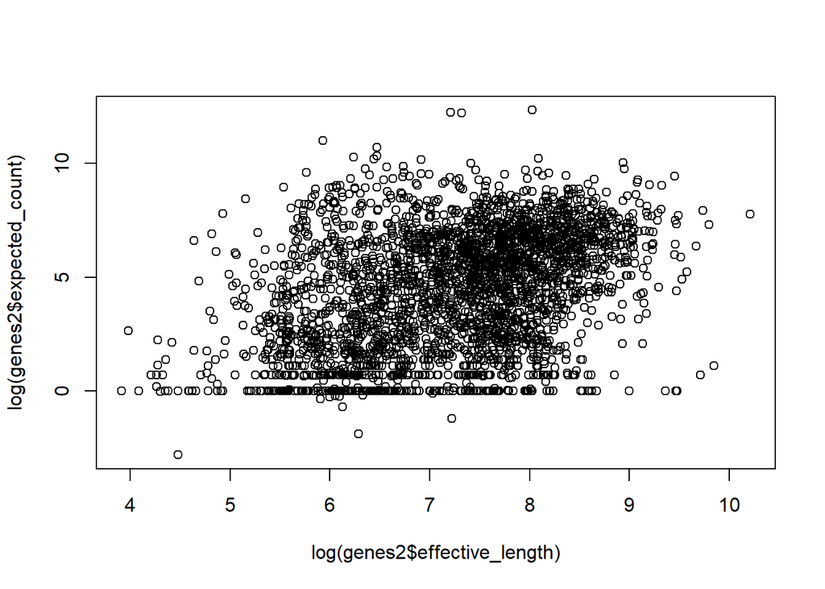

```r
plot(log(genes2$effective_length),
     log(genes2$expected_count))
```

**Make a histogram of the FPKM in genes2**

```r
genes2_fpkm <- log10(genes2$FPKM)
genes2_fpkm_pos <- genes2_fpkm[genes2_fpkm > 0]
median(genes2$FPKM)
```

```
## [1] 21.94
```

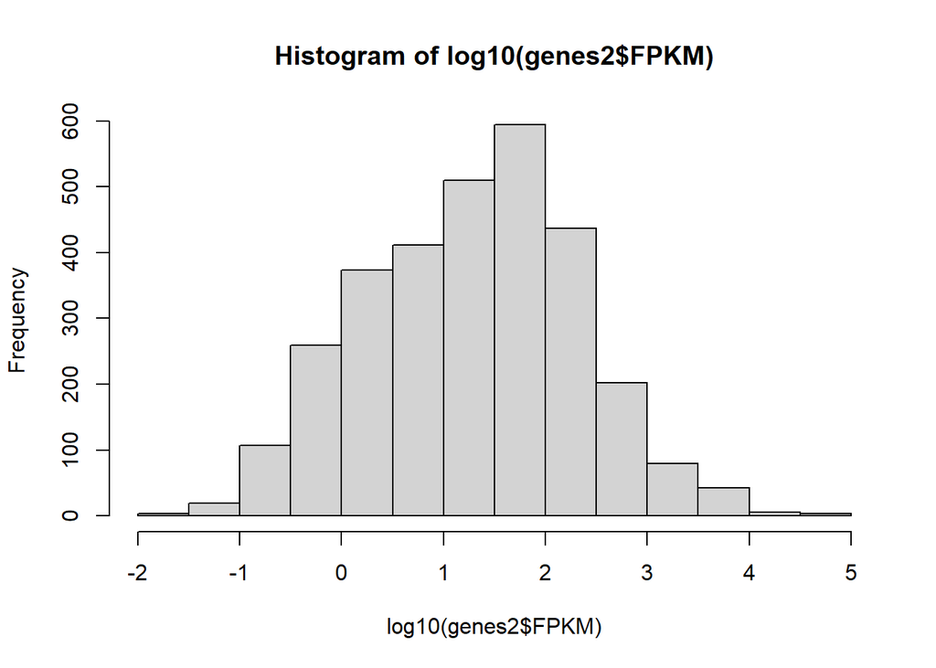

```r
hist(log10(genes2$FPKM))
```

**With isoforms2 , calculate the maximum IsoPct for each gene**

```r
head(isoforms2)
```

```
##     transcript_id         gene_id length effective_length expected_count   TPM
## 1 ENST00000367770 ENSG00000000457   2916          2880.32          17.48  2.26
## 2 ENST00000367771 ENSG00000000457   6364          6328.32         234.41 13.75
## 3 ENST00000367772 ENSG00000000457   3090          3054.32          77.27  9.41
## 4 ENST00000423670 ENSG00000000457   2077          2041.32          20.75  3.79
## 5 ENST00000470238 ENSG00000000457   1538          1502.32          10.06  2.50
## 6 ENST00000286031 ENSG00000000460   4355          4319.32           0.00  0.00
##    FPKM IsoPct
## 1  1.92   7.12
## 2 11.67  43.37
## 3  7.99  29.68
## 4  3.22  11.95
## 5  2.12   7.89
## 6  0.00   0.00
```

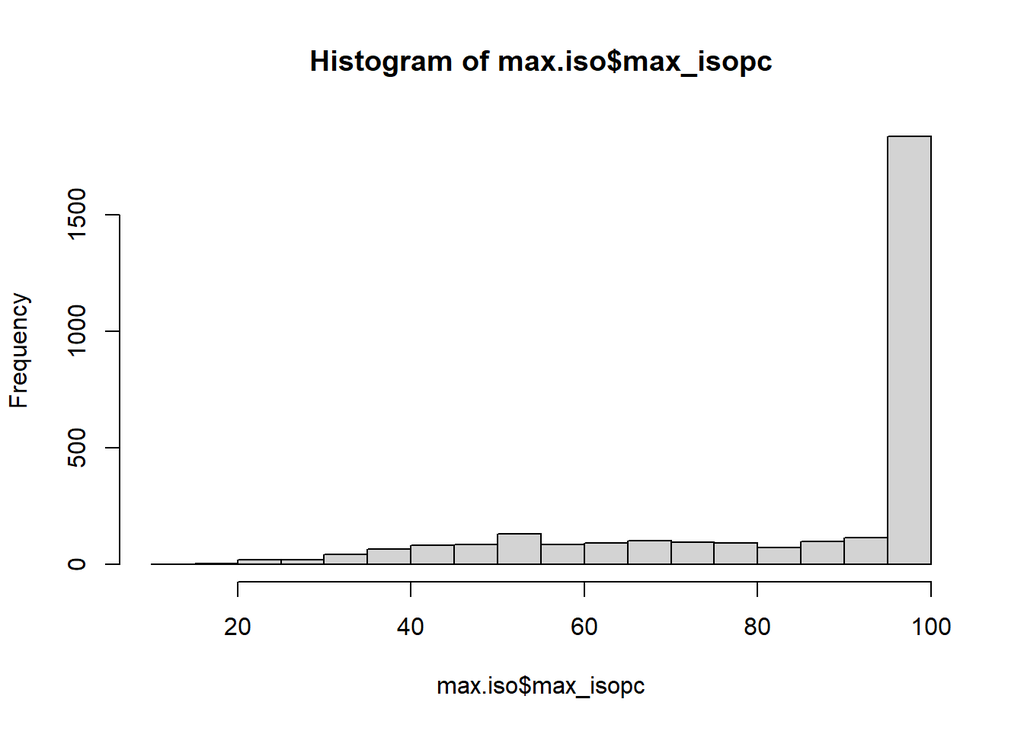

```r
max.iso <- isoforms2 %>%
              group_by(gene_id) %>%
              summarize(max_isopc = max(IsoPct))
hist(max.iso$max_isopc)
```

```r
mean(max.iso$max_isopc > 95)
```

```
## [1] 0.6026273
```

**Is there a relationship between total expression and the maximum IsoPct for each gene?**

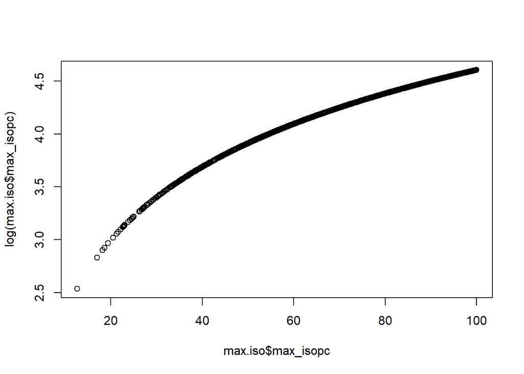

```r
plot(max.iso$max_isopc,
     log(max.iso$max_isopc))
```

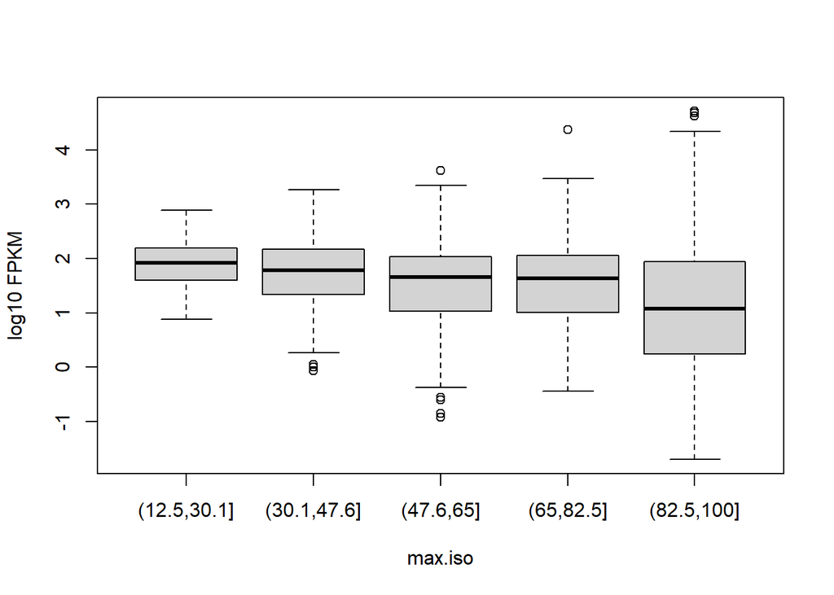

```r
boxplot(split(log10(genes2$FPKM),
              cut(max.iso$max_isopc, 5)), xlab="max.iso", ylab="log10 FPKM")
```

**Calculate the number of isoforms per gene, and plot the maximum IsoPct against the number of isoforms:**

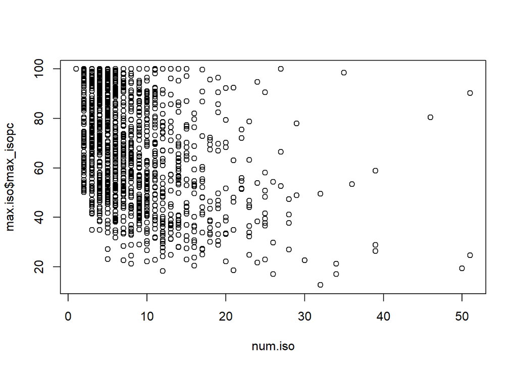

```r
num.iso <- as.numeric(table(isoforms2$gene_id))
plot(num.iso, max.iso$max_isopc)
```

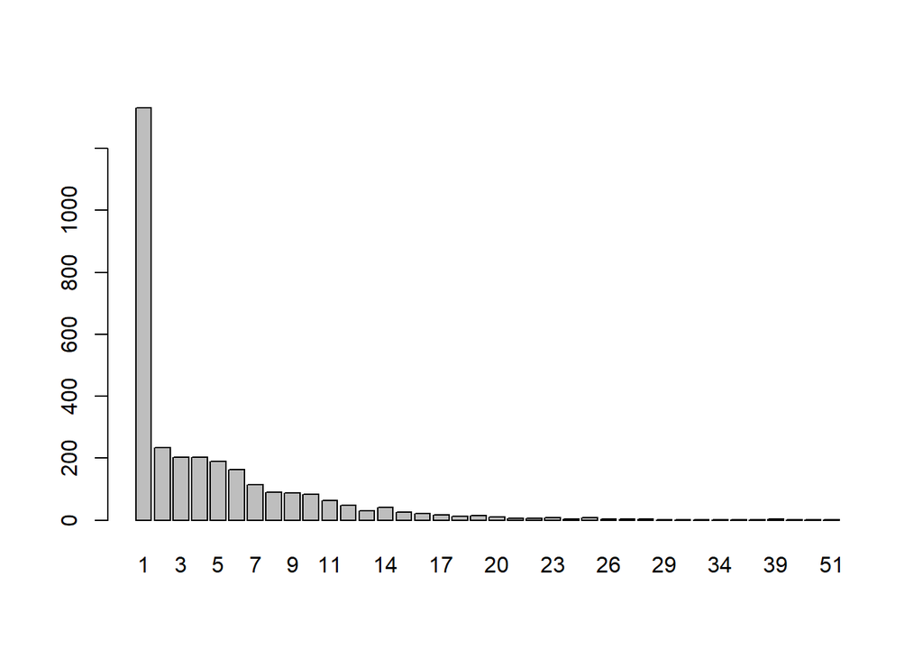

```r
barplot(table(num.iso))
```

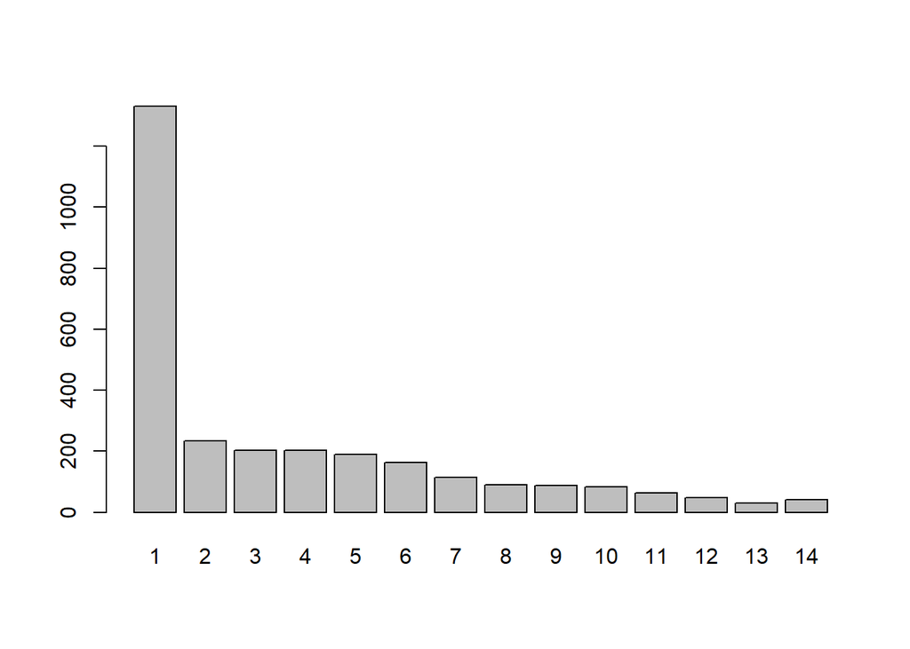

```r
barplot(table(num.iso[num.iso < 15]))
```

**TPM (transcripts per million)**, is a linear scaling of the FPKM, such that we would expect a gene with 1 TPM to have one molecule in a population of one million mRNAs.

## **Normalization and EDA of gene counts**

In this section, I will be examining the gene level expression from a study which studies the RNA-seq transcription profiling in airway smooth muscle tissue.

The treatment of interest in this study was **dexamethasone** that binds to the glucocorticoid receptor and in general provides an anti-inflammatory response. When used in asthma, it helps to suppress autoimmune reactions which have undesirable symptoms. We have eight samples, four treated and four untreated. The files needed for the analysis are found in the bioconductor package called **airway**.

### Count the number of reads which uniquely align to exns of different genes.

Load the data, contained in **bam** and **gtf** files. GTF files has information about genes in the subset of chromosomes on interest. Please note that the bam and gtf files analysed here are not full but a subset.

```r
# BiocManager::install("airway")
library(airway)
library(tidyverse)

dir <- system.file("extdata", package = "airway", mustWork = TRUE)
csv.file <- file.path(dir, "sample_table.csv") # contains th counts table for all genes and samples
sample.table <- read.csv(csv.file, row.names = 1)
bam.files <- file.path(dir, paste0(sample.table$Run, "_subset.bam")) # subset bam files
gtf.file <- file.path(dir, "Homo_sapiens.GRCh37.75_subset.gtf")
```

```r
sample.table %>%
  head %>%
  knitr::kable()
```

|  | SampleName | cell | dex | albut | Run | avgLength | Experiment | Sample | BioSample |
| --- | --- | --- | --- | --- | --- | --- | --- | --- | --- |
| SRR1039508 | GSM1275862 | N61311 | untrt | untrt | SRR1039508 | 126 | SRX384345 | SRS508568 | SAMN02422669 |
| SRR1039509 | GSM1275863 | N61311 | trt | untrt | SRR1039509 | 126 | SRX384346 | SRS508567 | SAMN02422675 |
| SRR1039512 | GSM1275866 | N052611 | untrt | untrt | SRR1039512 | 126 | SRX384349 | SRS508571 | SAMN02422678 |
| SRR1039513 | GSM1275867 | N052611 | trt | untrt | SRR1039513 | 87 | SRX384350 | SRS508572 | SAMN02422670 |
| SRR1039516 | GSM1275870 | N080611 | untrt | untrt | SRR1039516 | 120 | SRX384353 | SRS508575 | SAMN02422682 |
| SRR1039517 | GSM1275871 | N080611 | trt | untrt | SRR1039517 | 126 | SRX384354 | SRS508576 | SAMN02422673 |

### Building a counts matrix

```r
# BiocManager::install("Rsamtools")
library(Rsamtools)
bam.list <- BamFileList(bam.files) # yieldsize specifies how many reads to be read in at a time by any function that will use the bam files. Best to read all at once, why I do not specify it.
# BiocManager::install("GenomicFeatures")
library(GenomicFeatures) # helps to build a transcript database which contains all info about different genes, transcripts and exons
txdb <- makeTxDbFromGFF(gtf.file, format = "gtf") # txdb is a transcript database (db)
exons.by.gene <- exonsBy(txdb, by = "gene") # extract a GRanges list in which each element specifies a gene and within that element, we have exons for that gene.
```

Txdb objects are SQLite databases and can be saved with **saveDb** and can be loaded with **loadDb**.

Exploring the GRAnges object (exons.by.gene)

```r
exons.by.gene[[1]] %>%
  head %>%
  knitr::kable()
```

| seqnames | start | end | width | strand | exon_id | exon_name |
| --- | --- | --- | --- | --- | --- | --- |
| 1 | 11086580 | 11087705 | 1126 | - | 98 | ENSE00000818830 |
| 1 | 11090233 | 11090307 | 75 | - | 99 | ENSE00000472123 |
| 1 | 11090805 | 11090939 | 135 | - | 100 | ENSE00000743084 |
| 1 | 11094885 | 11094963 | 79 | - | 101 | ENSE00000743085 |
| 1 | 11097750 | 11097868 | 119 | - | 102 | ENSE00003482788 |
| 1 | 11097750 | 11097868 | 119 | - | 103 | ENSE00003520086 |

If we look at the first element in exons.by.gene object as in the table above, we get the exons for the first gene and the corresponding chromosome to which it is annotated.

```r
length(exons.by.gene)
```

```
## [1] 20
```

The length of exons.by.gene gives us the number of genes in our subset.

```r
summary(elementNROWS(exons.by.gene))
```

```
##    Min. 1st Qu.  Median    Mean 3rd Qu.    Max.
##    1.00    1.00    3.00   13.95   18.75   79.00
```

```r
library(GenomicAlignments)
se <- summarizeOverlaps(exons.by.gene,
                        bam.list,
                        mode = "Union",
                        singleEnd = FALSE, # we want to count paired end reads
                        ignore.strand = TRUE, # we have unstranded rna seq data
                        fragments = TRUE) # used when we have paired end data
colData(se) <- DataFrame(sample.table)
```

So the actual count table is stored in a SummarizedExperiment in the assay slot.

```r
colData(se)
```

```
## DataFrame with 8 rows and 9 columns
##             SampleName        cell         dex       albut         Run
##            <character> <character> <character> <character> <character>
## SRR1039508  GSM1275862      N61311       untrt       untrt  SRR1039508
## SRR1039509  GSM1275863      N61311         trt       untrt  SRR1039509
## SRR1039512  GSM1275866     N052611       untrt       untrt  SRR1039512
## SRR1039513  GSM1275867     N052611         trt       untrt  SRR1039513
## SRR1039516  GSM1275870     N080611       untrt       untrt  SRR1039516
## SRR1039517  GSM1275871     N080611         trt       untrt  SRR1039517
## SRR1039520  GSM1275874     N061011       untrt       untrt  SRR1039520
## SRR1039521  GSM1275875     N061011         trt       untrt  SRR1039521
##            avgLength  Experiment      Sample    BioSample
##            <integer> <character> <character>  <character>
## SRR1039508       126   SRX384345   SRS508568 SAMN02422669
## SRR1039509       126   SRX384346   SRS508567 SAMN02422675
## SRR1039512       126   SRX384349   SRS508571 SAMN02422678
## SRR1039513        87   SRX384350   SRS508572 SAMN02422670
## SRR1039516       120   SRX384353   SRS508575 SAMN02422682
## SRR1039517       126   SRX384354   SRS508576 SAMN02422673
## SRR1039520       101   SRX384357   SRS508579 SAMN02422683
## SRR1039521        98   SRX384358   SRS508580 SAMN02422677
```

```r
rowRanges(se)
```

```
## GRangesList object of length 20:
## $ENSG00000009724
## GRanges object with 18 ranges and 2 metadata columns:
##        seqnames            ranges strand |   exon_id       exon_name
##           <Rle>         <IRanges>  <Rle> | <integer>     <character>
##    [1]        1 11086580-11087705      - |        98 ENSE00000818830
##    [2]        1 11090233-11090307      - |        99 ENSE00000472123
##    [3]        1 11090805-11090939      - |       100 ENSE00000743084
##    [4]        1 11094885-11094963      - |       101 ENSE00000743085
##    [5]        1 11097750-11097868      - |       102 ENSE00003482788
##    ...      ...               ...    ... .       ...             ...
##   [14]        1 11106948-11107176      - |       111 ENSE00003467404
##   [15]        1 11106948-11107176      - |       112 ENSE00003489217
##   [16]        1 11107260-11107280      - |       113 ENSE00001833377
##   [17]        1 11107260-11107284      - |       114 ENSE00001472289
##   [18]        1 11107260-11107290      - |       115 ENSE00001881401
##   -------
##   seqinfo: 1 sequence from an unspecified genome; no seqlengths
##
## ...
## <19 more elements>
```

```r
dim(assay(se))
```

```
## [1] 20  8
```

```r
colSums(assay(se))
```

```
## SRR1039508 SRR1039509 SRR1039512 SRR1039513 SRR1039516 SRR1039517 SRR1039520
##       6478       6501       7699       6801       8009      10849       5254
## SRR1039521
##       9168
```

```r
# BiocManager::install("Rsubread")
library(Rsubread)

# function below is an alternate function to count read in genes
fc <- featureCounts(bam.files,
                    annot.ext = gtf.file,
                    isGTFAnnotationFile = TRUE,
                    isPairedEnd = TRUE)
```

[output not shown]

[output cut: 38 more lines]

[output not shown]

```r
names(fc)
```

```
## [1] "counts"     "annotation" "targets"    "stat"
```

```r
fc$counts %>%
  head %>%
  knitr::kable()
```

|  | SRR1039508_subset.bam | SRR1039509_subset.bam | SRR1039512_subset.bam | SRR1039513_subset.bam | SRR1039516_subset.bam | SRR1039517_subset.bam | SRR1039520_subset.bam | SRR1039521_subset.bam |
| --- | --- | --- | --- | --- | --- | --- | --- | --- |
| ENSG00000175262 | 0 | 0 | 4 | 1 | 0 | 0 | 1 | 0 |
| ENSG00000215785 | 0 | 0 | 1 | 0 | 0 | 0 | 0 | 0 |
| ENSG00000264181 | 0 | 0 | 0 | 0 | 0 | 0 | 0 | 0 |
| ENSG00000207213 | 0 | 0 | 0 | 0 | 0 | 0 | 0 | 0 |
| ENSG00000120948 | 2752 | 2080 | 3353 | 1617 | 3521 | 3716 | 2220 | 1991 |
| ENSG00000009724 | 38 | 28 | 66 | 24 | 42 | 41 | 47 | 36 |

below I compare the first sample counts for the summarizeOverlaps call and for the counts.

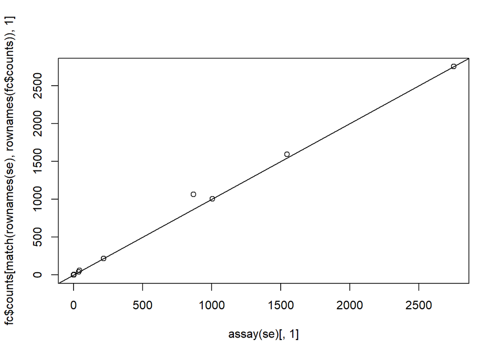

```r
plot(assay(se)[, 1], fc$counts[match(rownames(se),
                                      rownames(fc$counts)), 1]);
abline(0, 1)
```

From the graph above we see that the counts fall in the y = x line, indicatint that both methods yield similar results.

## **Normalizing for sequencing depth**

### By taking the log2

```r
library(airway)
data(airway)
airway
```

```
## class: RangedSummarizedExperiment
## dim: 63677 8
## metadata(1): ''
## assays(1): counts
## rownames(63677): ENSG00000000003 ENSG00000000005 ... ENSG00000273492
##   ENSG00000273493
## rowData names(10): gene_id gene_name ... seq_coord_system symbol
## colnames(8): SRR1039508 SRR1039509 ... SRR1039520 SRR1039521
## colData names(9): SampleName cell ... Sample BioSample
```

```r
colData(airway)
```

```
## DataFrame with 8 rows and 9 columns
##            SampleName     cell      dex    albut        Run avgLength
##              <factor> <factor> <factor> <factor>   <factor> <integer>
## SRR1039508 GSM1275862  N61311     untrt    untrt SRR1039508       126
## SRR1039509 GSM1275863  N61311     trt      untrt SRR1039509       126
## SRR1039512 GSM1275866  N052611    untrt    untrt SRR1039512       126
## SRR1039513 GSM1275867  N052611    trt      untrt SRR1039513        87
## SRR1039516 GSM1275870  N080611    untrt    untrt SRR1039516       120
## SRR1039517 GSM1275871  N080611    trt      untrt SRR1039517       126
## SRR1039520 GSM1275874  N061011    untrt    untrt SRR1039520       101
## SRR1039521 GSM1275875  N061011    trt      untrt SRR1039521        98
##            Experiment    Sample    BioSample
##              <factor>  <factor>     <factor>
## SRR1039508  SRX384345 SRS508568 SAMN02422669
## SRR1039509  SRX384346 SRS508567 SAMN02422675
## SRR1039512  SRX384349 SRS508571 SAMN02422678
## SRR1039513  SRX384350 SRS508572 SAMN02422670
## SRR1039516  SRX384353 SRS508575 SAMN02422682
## SRR1039517  SRX384354 SRS508576 SAMN02422673
## SRR1039520  SRX384357 SRS508579 SAMN02422683
## SRR1039521  SRX384358 SRS508580 SAMN02422677
```

The table above contains metadata.

```r
rowRanges(airway)
```

```
## GRangesList object of length 63677:
## $ENSG00000000003
## GRanges object with 17 ranges and 2 metadata columns:
##        seqnames            ranges strand |   exon_id       exon_name
##           <Rle>         <IRanges>  <Rle> | <integer>     <character>
##    [1]        X 99883667-99884983      - |    667145 ENSE00001459322
##    [2]        X 99885756-99885863      - |    667146 ENSE00000868868
##    [3]        X 99887482-99887565      - |    667147 ENSE00000401072
##    [4]        X 99887538-99887565      - |    667148 ENSE00001849132
##    [5]        X 99888402-99888536      - |    667149 ENSE00003554016
##    ...      ...               ...    ... .       ...             ...
##   [13]        X 99890555-99890743      - |    667156 ENSE00003512331
##   [14]        X 99891188-99891686      - |    667158 ENSE00001886883
##   [15]        X 99891605-99891803      - |    667159 ENSE00001855382
##   [16]        X 99891790-99892101      - |    667160 ENSE00001863395
##   [17]        X 99894942-99894988      - |    667161 ENSE00001828996
##   -------
##   seqinfo: 722 sequences (1 circular) from an unspecified genome
##
## ...
## <63676 more elements>
```

The above this is GRangesList, where each element is a gene and it contains the exons of that gene.

```r
head(assay(airway))
```

```
##                 SRR1039508 SRR1039509 SRR1039512 SRR1039513 SRR1039516
## ENSG00000000003        679        448        873        408       1138
## ENSG00000000005          0          0          0          0          0
## ENSG00000000419        467        515        621        365        587
## ENSG00000000457        260        211        263        164        245
## ENSG00000000460         60         55         40         35         78
## ENSG00000000938          0          0          2          0          1
##                 SRR1039517 SRR1039520 SRR1039521
## ENSG00000000003       1047        770        572
## ENSG00000000005          0          0          0
## ENSG00000000419        799        417        508
## ENSG00000000457        331        233        229
## ENSG00000000460         63         76         60
## ENSG00000000938          0          0          0
```

The table above contains the counts of the various genes for each sample. The counts are the number of paired-end reads which align to each gene.

However, to be accurate about the number of reads which align to each gene, there are a number of issues to account for. One of them is the sequencing depth. The sequencing depth is the number of reads which aligned to genes.

```r
colSums(assay(airway))
```

```
## SRR1039508 SRR1039509 SRR1039512 SRR1039513 SRR1039516 SRR1039517 SRR1039520
##   20637971   18809481   25348649   15163415   24448408   30818215   19126151
## SRR1039521
##   21164133
```

The results from the command above gives the number of paired end reads which align the genes of each sample and we can sort that by million.

```r
sort(colSums(assay(airway)))/ 1e6
```

```
## SRR1039513 SRR1039509 SRR1039520 SRR1039508 SRR1039521 SRR1039516 SRR1039512
##   15.16342   18.80948   19.12615   20.63797   21.16413   24.44841   25.34865
## SRR1039517
##   30.81821
```

We see the range is from 15 million to 30 million and this is a technical artifact we want to account for. If we also just look at the raw counts, we realise that the variance is much higher for large counts than for small counts, so if we compare the raw counts vector, the genes that have a very high count would be more important, and they would be adding more information to the distance than the small count genes.

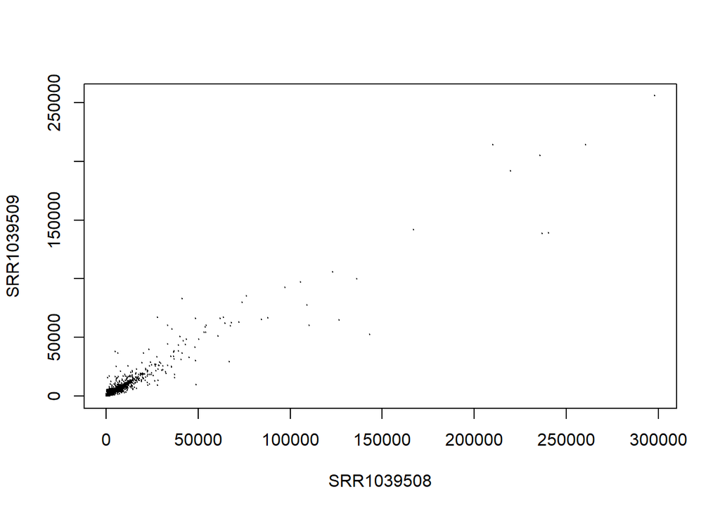

```r
plot(assay(airway)[, 1:2], cex = 0.1)
```

So we’re going to first try out taking the log and dividing by a robust estimate of the sequencing depth, in order to make a distance comparison between samples. In order to have a robust estimate of the differences in sequencing depth, we’re going to use the DESeq2 package.

```r
# BiocManager::install("DESeq2")
library(DESeq2)

dds <- DESeqDataSet(airway, design =  ~ cell + dex) # you can also put ~ 1 if you do not know what to ut, just to estimate the size factors.
```

We can also make a *DESeqDataSet* from count matrix and column data.

The following estimates size factors to account for differences in sequencing depth, and is only necessary to have the `logcounts` object below.

```r
library(rafalib)

dds <- estimateSizeFactors(dds) # gives robust estimate in differences in sequencing depth.
sizeFactors(dds)
```

```
## SRR1039508 SRR1039509 SRR1039512 SRR1039513 SRR1039516 SRR1039517 SRR1039520
##  1.0236476  0.8961667  1.1794861  0.6700538  1.1776714  1.3990365  0.9207787
## SRR1039521
##  0.9445141
```

```r
colSums(counts(dds))
```

```
## SRR1039508 SRR1039509 SRR1039512 SRR1039513 SRR1039516 SRR1039517 SRR1039520
##   20637971   18809481   25348649   15163415   24448408   30818215   19126151
## SRR1039521
##   21164133
```

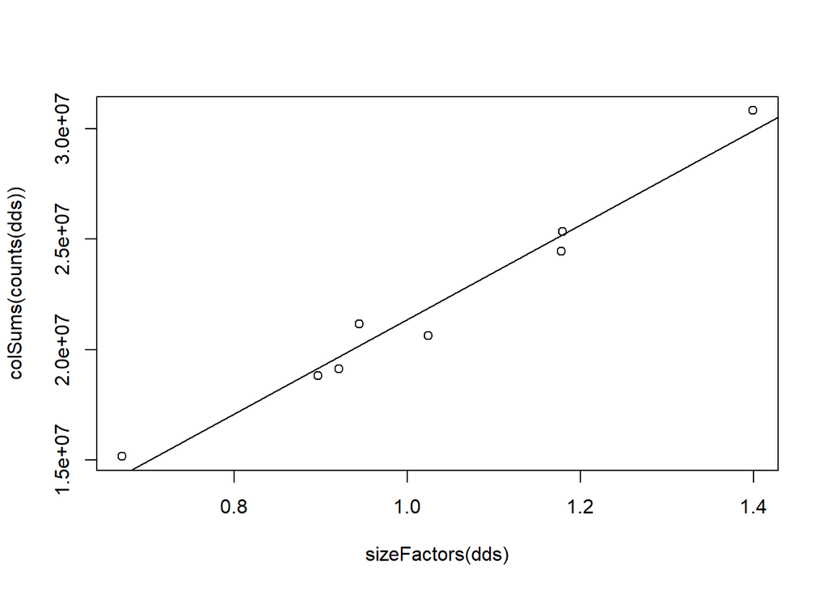

```r
plot(sizeFactors(dds), colSums(counts(dds)))
abline(lm(colSums(counts(dds)) ~ sizeFactors(dds) + 0) )
```

So the size factors are generally around one. When they’re lower, it indicates that a sample had lower sequencing depth.And when they’re higher– for here, 1.4– it indicates that a sample had higher sequencing depth.

So we can see that a fitted line which also goes through zero generally follows the column sums. But the reason why the size factors are considered more robustis that if we had a single count with a very large value– so if one of the genes had 10 million counts– this would have a huge effect on the column sums, but it would have almost no effect on the size factors, because they’re calculated using the median.

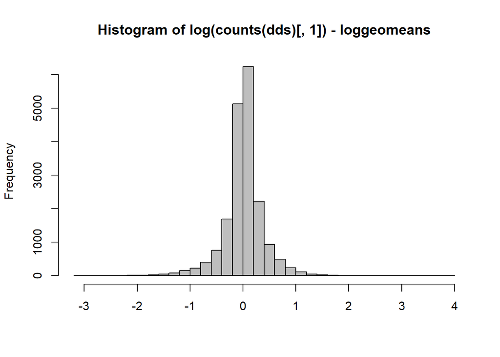

```r
loggeomeans <- rowMeans(log(counts(dds)))
hist(log(counts(dds)[, 1]) - loggeomeans,
     col = "grey", maint ="", xlab = "", breaks = 40)
```

We can take a matrix of the log counts normalised by sequencing depth:

```r
log.norm.count <- log2(counts(dds, normalized = TRUE) + 1)
```

To see what would happen if we had not normalised by sequencing depth:

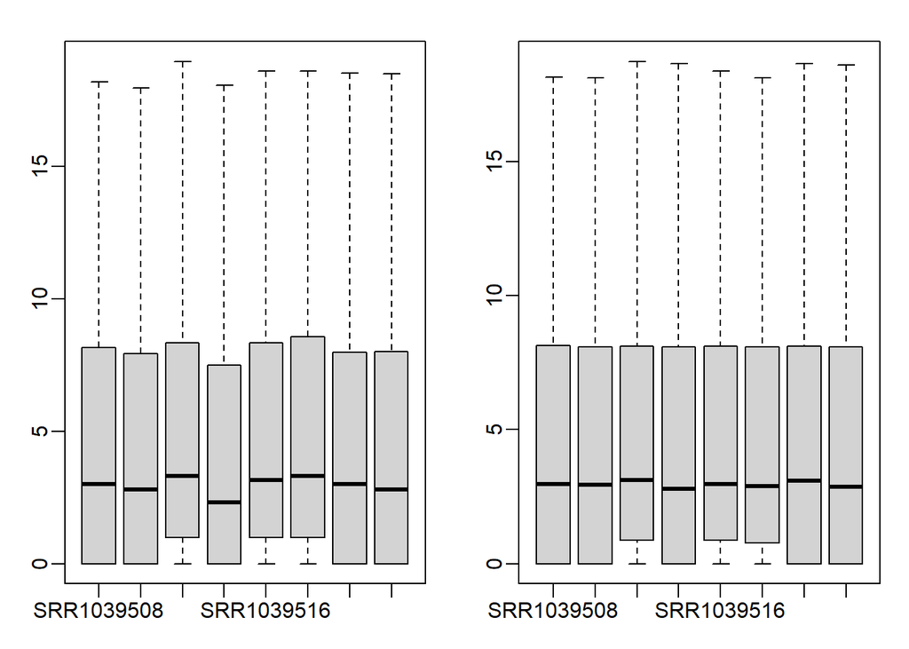

```r
rs <- rowSums(counts(dds))
mypar(1, 2)
boxplot(log2(counts(dds)[rs > 0, ] + 1)) # not normalised
boxplot(log.norm.count[rs > 0, ]) # normalised
```

You can see that from the top of the box, which is the 3/4 quartile,and from the median, for example, which is the thick line, in the left plot is jagged and on the right plot it’s more flat. So normalizing for sequencing depth is an important first step. And we’ve also taken the log, and the log has brought the data onto a more comparable scale.

Plotting distances between two samples for the normalised data

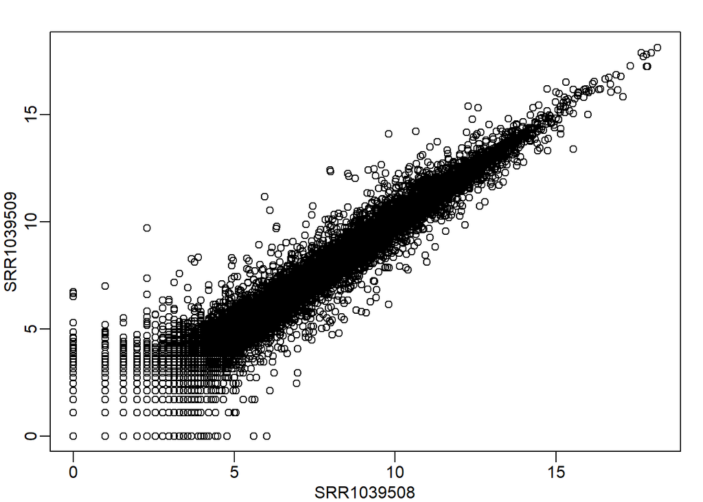

```r
mypar(1, 1)
plot(log.norm.count[, 1:2])
```

We see from the plot above that there is more stable variance between the two samples than in the previous related plot.So the variance between the two samples is more constant along the range. So whereas before, this trumpeted out towards the higher values, now the variance between the two samples is more flat. Although at the bottom here, where the counts become very close to zero, there is a higher spread, and that’s what we’re going to examine in the next video.

### By stabilising the count variance

So in this section, we’re going to discuss a more sophisticated transformation, which helps to stabilize the variance at different levels of the mean. We use the `rlog` from the DESeq2 package, which is suitable when the size factors vary widely. The result of using the rlog transformation is to shrink together the values for the genes that have very low counts, and that’s where the term regularization comes in, which is typically, in statistics, a shrinkage. And for the genes that have medium to high counts, the rlog will be very close to the log2 transform. So we can immediately use the same plot to compare just the rlog values for two samples.

```r
rld <- rlog(dds)
```

So we can immediately use the same plot to compare just the rlog values for two samples. So we can see now that at the low end– so, for example, when the log2 is less than 1 in this area, the values for the two samples are shrunk together to the identity line.

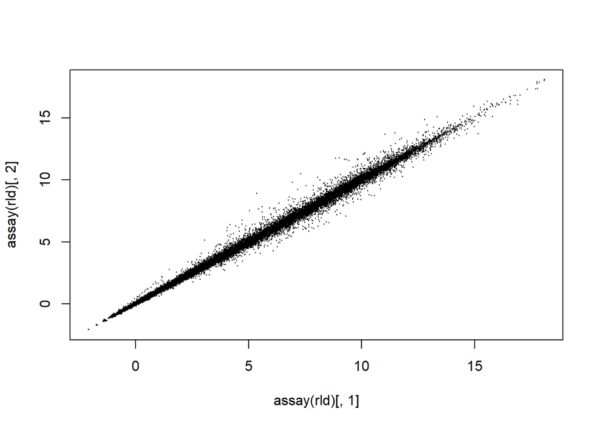

```r
plot(assay(rld)[, 1], assay(rld)[, 2], cex = 0.1)
```

So another plot to examine the difference between these two transformations, the log2 and the rlog, is in the `vsn` package, which contains a mean standard deviation plot. And the means standard deviation plot for each gene calculates the mean over all samples and the standard deviation over all samples.

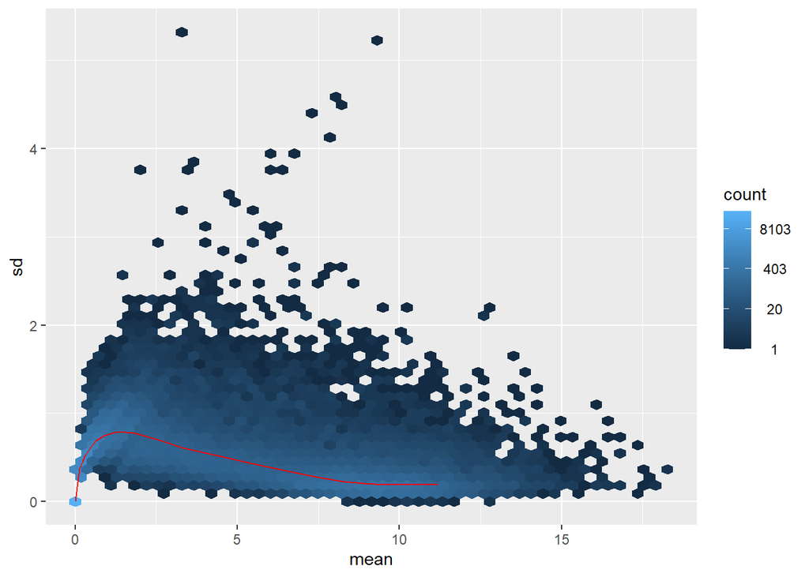

```r
# BiocManager::install("vsn")
library(vsn)
mypar(1, 2)
meanSdPlot(log.norm.count, ranks = FALSE, ylim = c(0, 3))
```

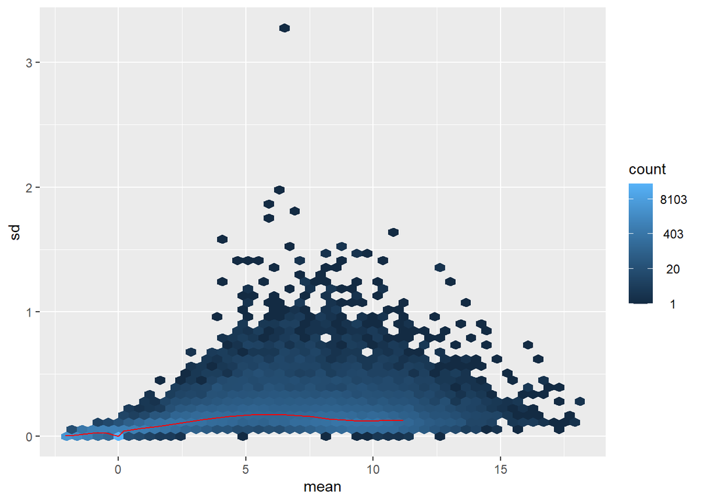

```r
meanSdPlot(assay(rld), ranks = FALSE, ylim = c(0, 3))
```

And by comparing the two plots, you can see that the standard deviation spikes early for the log2 plus 1 matrix, and it slowly builds up from 0 for the rlog matrix. So for the rlog matrix, the genes that have a count larger than 5, so for a count larger than 32, those are the genes with the high standard deviation. Whereas on the left, the genes that have a mean count of 1 are the genes that have the high standard deviation. So this stabilization of the variance is a useful property of the rlog.

**Principal components analysis**

One of the most important plots that we can make for exploratory data analysis is a principal component plot.

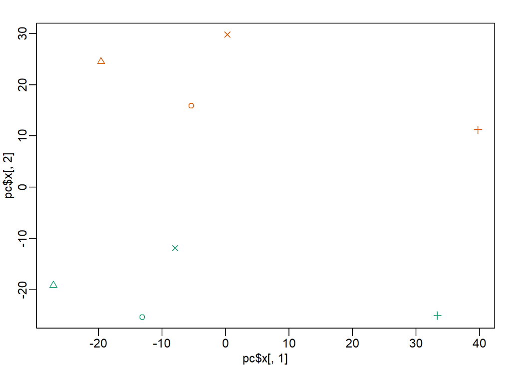

```r
mypar()
rv <- apply(log.norm.count, 1, var)
topgenes <- head(order(rv, decreasing = TRUE), 500)
pc <- prcomp(t(log.norm.count[topgenes, ]))
plot(pc$x[, 1], pc$x[, 2],
     col = colData(dds)$dex,
     pch = as.integer(colData(dds)$cell))
```

Plotting pca on the rlog object

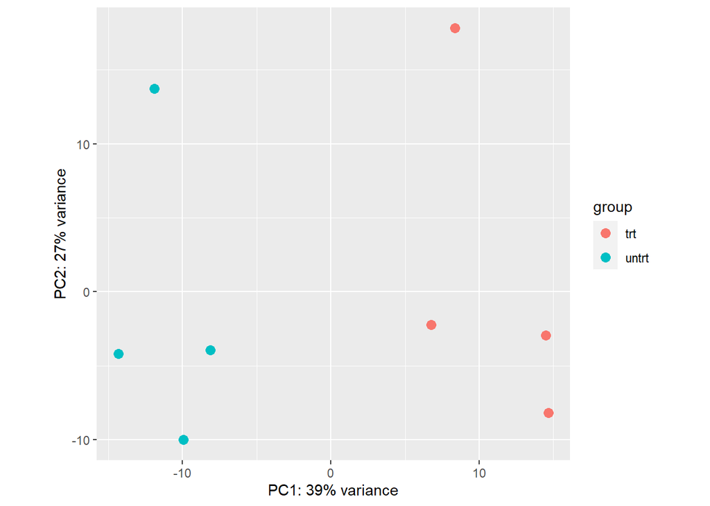

```r
plotPCA(rld, intgroup = "dex")
```

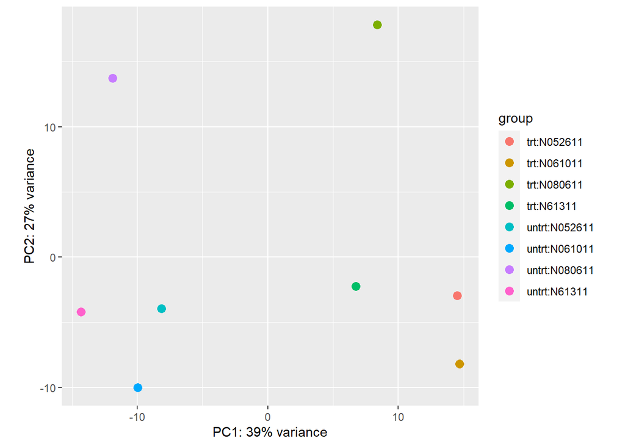

```r
plotPCA(rld, intgroup = c("dex", "cell"))
```

PCA plot with `ggplot` library

```r
library(ggplot2)
(data <- plotPCA(rld, intgroup = c("dex", "cell"), returnData = TRUE))
```

```
##                   PC1        PC2         group   dex    cell       name
## SRR1039508 -14.326791  -4.205271  untrt:N61311 untrt  N61311 SRR1039508
## SRR1039509   6.752236  -2.242264    trt:N61311   trt  N61311 SRR1039509
## SRR1039512  -8.128701  -3.950350 untrt:N052611 untrt N052611 SRR1039512
## SRR1039513  14.500816  -2.940329   trt:N052611   trt N052611 SRR1039513
## SRR1039516 -11.887297  13.728272 untrt:N080611 untrt N080611 SRR1039516
## SRR1039517   8.371955  17.815856   trt:N080611   trt N080611 SRR1039517
## SRR1039520  -9.962960 -10.012013 untrt:N061011 untrt N061011 SRR1039520
## SRR1039521  14.680742  -8.193902   trt:N061011   trt N061011 SRR1039521
```

```r
(percentVar <- 100 * round(attr(data, "percentVar"), 2))
```

```
## [1] 39 27
```

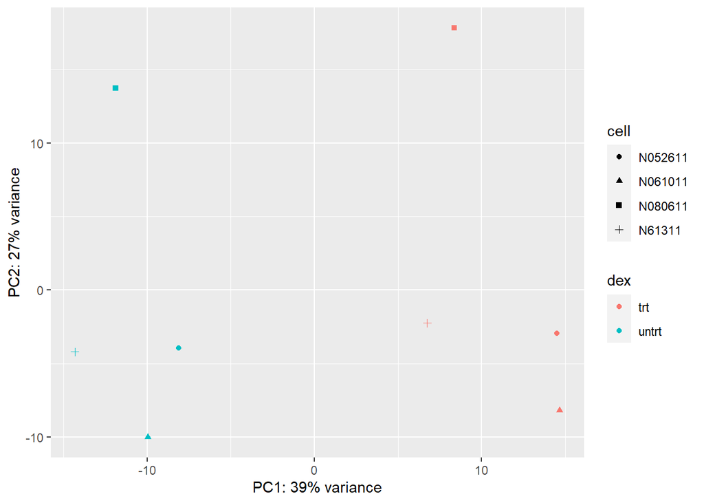

```r
makeLab <- function(x, pc) paste0("PC", pc, ": ", x, "% variance")
ggplot(data, aes(PC1, PC2, col = dex, shape = cell)) +
  geom_point() +
  xlab(makeLab(percentVar[1], 1)) +
  ylab(makeLab(percentVar[2], 2))
```

So now we can see we have the color separating treated and untreated,and the plotting symbol designates the cell type. So the principal component plot is a highly recommended exploratory plot.

And the last plot we’re going to make in this exploratory section is a hierarchical clustering based on the Euclidean distance between the transformed count matrices.

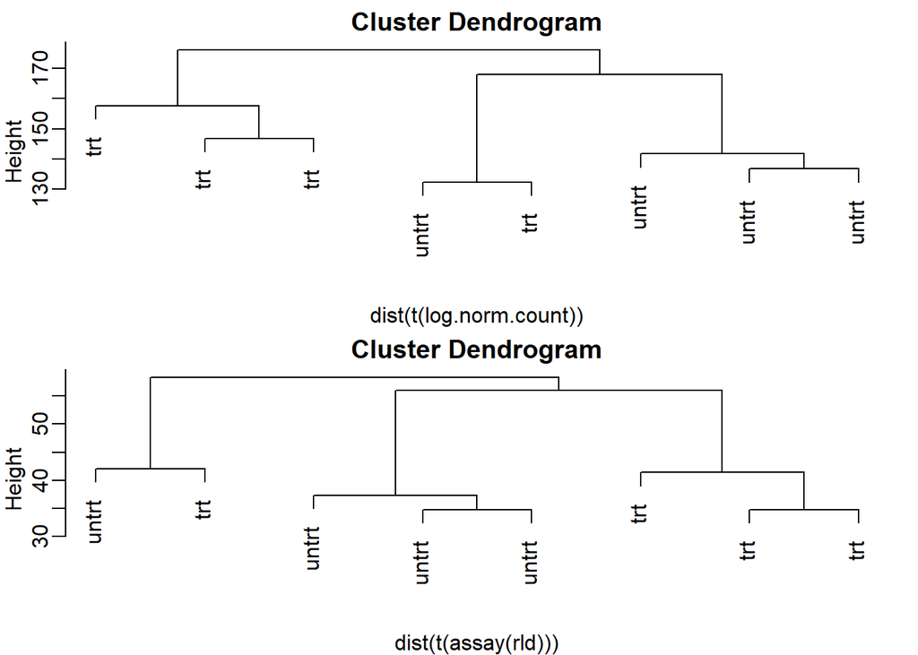

```r
mypar(2, 1)
plot(hclust(dist(t(log.norm.count))), labels = colData(dds)$dex)
plot(hclust(dist(t(assay(rld)))), labels = colData(rld)$dex)
```